# `python` Intermediate

### `Matplotlib` introduction and `NumPy` extras

## Mauricio Sevilla

`email= j.sevillam@uniandes.edu.co`

01.04.19

During this week, we are going to learn to use one of the most used plotting libraries available on `python`, [Matplotlib](https://matplotlib.org/).

As we are going to use some `array`-like structures, we are also going to keep working on [NumPy](http://www.numpy.org/).

Firts of all, `matplotlib` is a huge library, so we are going to use (Not forever), just a *small* module, `pylab`. This package can be imported, but we are going to use a standard method, such that,

```python
import numpy as np
import matplotlib.pylab as plt
```

Where all the `plt` functions belong to the plot library.

Second of all, we have to understand that `matplotlib` does not plot functions, it plots `array`-like structures or numbers, such as `numpy.array`s, `list`s, `int`s, `float`s and so on.

Let see some examples, consider the following list

```python
x=[1,3,7,4]
```

we want to plot these points, easily we can use the `matplotlib.pylab.plot` function.

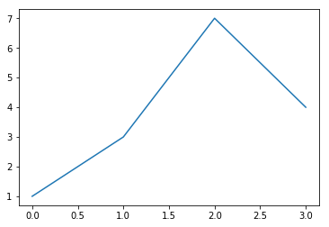

```python
plt.plot(x)
```

1. We can plot a single `array` (`matplotlib` uses a `range(len(.))` for the $x$ axis) on the latest `matplotlib` versions.
2. By default, it plots lines. (Can be changed)
3. On the notebook, we get the plot as the cell output, on a `python` script, we should also use `plt.show()`. Just for you not to get confused about it, we are going to use the line `plt.show()` in all the cells with plots.

One can give the plot additional options, for example, let us use points instead of lines on our plot

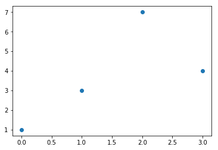

```python
plt.plot(x,'o')
plt.show()
```

what if, additionally I want the points to be red,

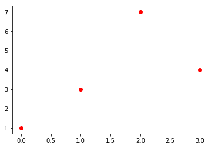

```python
plt.plot(x,'ro')
plt.show()
```

if we want to have more than one plot, we use `matplotlib.pylab.plot` more than once before the `matplotlib.pylab.show()`.

On the Jupyter notebook, we must use them on the same cell.

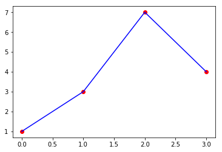

```python
plt.plot(x,'ro')
plt.plot(x,'b')
plt.show()
```

Order is important!

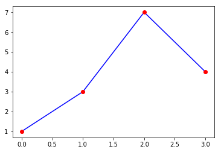

```python
plt.plot(x,'b')
plt.plot(x,'ro')
plt.show()
```

One can use severad already defined colors

| Character | Color |
| --- | --- |
| `'b'` | Blue |
| `'g'` | Green |
| `'r'` | Red |
| `'c'` | Cyan |
| `'m'` | Magenta |
| `'y'` | Yellow |
| `'k'` | Black |
| `'w'` | White |

The point style can be choosen from,

| Character | Description | Character | Description |
| --- | --- | --- | --- |
| `'.'` | Point | `'s'` | Square |
| `','` | Pixel | `'p'` | Pentagon |
| `'o'` | Circle | `'*'` | Star |
| `'v'` | Triangle Down | `'h'` | Hexagon 1 |
| `'^'` | Triangle Up | `'H'` | Hexagon 2 |
| `'<'` | Triangle Left | `'+'` | Plus |
| `'>'` | Triangle Right | `'x'` | x |
| `'1'` | Tri-Down | `'D'` | Diamond |
| `'2'` | Tri-Up | `'d'` | Thin Diamond |
| `'3'` | Tri-Left | `'\|'` | Vertical Line |
| `'4'` | Tri-Right | `'_'` | Horizontal Line |

The lines allow us to choose among,

| Character | Description |
| --- | --- |
| `'-'` | Solid |
| `'--'` | Dashed |
| `'-.'` | Dash-dot |
| `':'` | Dotted |

### Some Examples

```
'b'    # blue markers with default shape
'ro'   # red circles
'g-'   # green solid line
'--'   # dashed line with default color
'k^:'  # black triangle_up markers connected by a dotted line
```

Let us use a bigger set of data, first we are going to generate some points as we did on the last homework, and then, we will load an external file.

```python
def fun(x):
    return np.sin(5*x)*np.exp(-x/5)
```

The function `numpy.linspace` allows us to create an array with a certain amount of numbers on a given interval,

```python
x=np.linspace(0,10,1000)
```

And, after that, create a new one applying a function to them,

```python
y1=fun(x)
```

The plot, is done as simply as

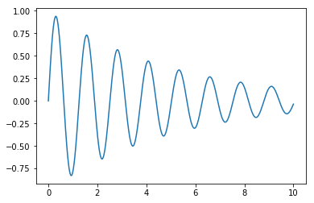

```python
plt.plot(x,y1)
plt.show()
```

We can add a legend,

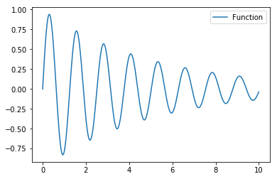

```python
plt.plot(x,y1,label='Function')
plt.legend()
plt.show()
```

Or even labels, on $x$

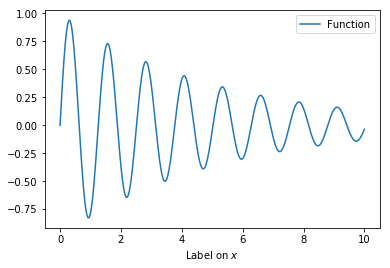

```python
plt.plot(x,y1,label='Function')
plt.xlabel('Label on $x$')
plt.legend()
plt.show()
```

or in both $y$ and $x$ directions

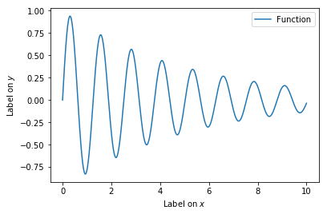

```python
plt.plot(x,y1,label='Function')
plt.xlabel('Label on $x$')
plt.ylabel('Label on $y$')
plt.legend()
plt.show()
```

And a title!

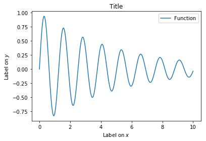

```python
plt.plot(x,y1,label='Function')
plt.title('Title')
plt.xlabel('Label on $x$')
plt.ylabel('Label on $y$')
plt.legend()
plt.show()
```

## Figures

There is a better way to do it, at the beginning it looks longer, but it will help us later when creating multiplots, it is using `matplotlib.pylab.figure`s.

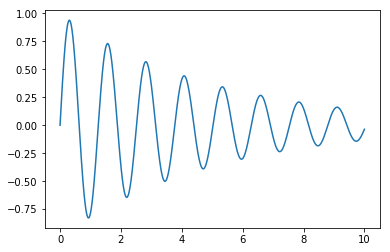

```python
fig=plt.figure()
ax=fig.add_subplot(111)
ax.plot(x,y1)
plt.show()
```

Here, the labels are added a little bit different

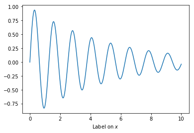

```python
fig=plt.figure()
ax=fig.add_subplot(111)
ax.plot(x,y1)
ax.set_xlabel('Label on $x$')
plt.show()
```

and so on,

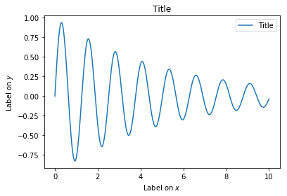

```python
fig=plt.figure()
ax=fig.add_subplot(111)
ax.plot(x,y1,label='Title')
ax.set_xlabel('Label on $x$')
ax.set_ylabel('Label on $y$')
ax.set_title('Title')
plt.legend()
plt.show()
```

## Spectra

Let us use several experimental data on external files, you will be able to see the spectrum of a Deuterium and Tungsten (Wolfram) lamp, measued at the Optics Laboratory at the Universidad Nacional de Colombia.

On the following link you will find a folder with the data,

```python
url='https://raw.githubusercontent.com/jmsevillam/Herramientas-Computacionales-UniAndes/master/Data/Spectra/'
```

We are going to open the files by using the `numpy.genfromtxt` function

```python
Deuterium=np.genfromtxt(url+'D.txt')
Tungsten=np.genfromtxt(url+'W.txt')
Both=np.genfromtxt(url+'W+D.txt')
```

This is one of the most important thins when working with data as we are,

```python
print(Deuterium)
```

```
[[ 1.97750921e+02  4.96420000e-04]
 [ 1.97952761e+02  3.73730000e-04]
 [ 1.98154619e+02  1.24860000e-04]
 ...
 [ 1.02398952e+03  3.67800000e-05]
 [ 1.02423379e+03 -1.89400000e-05]
 [ 1.02447807e+03  2.32180000e-04]]
```

```python
print(np.shape(Deuterium))
```

```
(3648, 2)
```

There are several ways to get the columns of the file, first

```python
print(np.shape(Deuterium.T))
```

```
(2, 3648)
```

```python
print(Deuterium.T)
```

```
[[ 1.97750921e+02  1.97952761e+02  1.98154619e+02 ...  1.02398952e+03
   1.02423379e+03  1.02447807e+03]
 [ 4.96420000e-04  3.73730000e-04  1.24860000e-04 ...  3.67800000e-05
  -1.89400000e-05  2.32180000e-04]]
```

Second, using a slicing strucure to extract the $n$th column,

```python
print(Deuterium[:,0])
```

```
[ 197.75092074  197.952761    198.15461887 ... 1023.98952476 1024.23379367
 1024.47806826]
```

Thus,

```python
xD=Deuterium[:,0]
yD=Deuterium[:,1]
xW=Tungsten[:,0]
yW=Tungsten[:,1]
xB=Both[:,0]
yB=Both[:,1]
print(yD)
```

```
[ 4.9642e-04  3.7373e-04  1.2486e-04 ...  3.6780e-05 -1.8940e-05
  2.3218e-04]
```

Again, the multiple plot goes as,

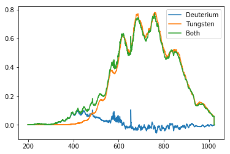

```python
fig=plt.figure()
ax=fig.add_subplot(111)
ax.plot(xD,yD,label='Deuterium')
ax.plot(xW,yW,label='Tungsten')
ax.plot(xB,yB,label='Both')
ax.legend()
plt.show()
```

What if, we would like to have the three plots separated, here is where the figures and axes structure becomes useful, we may define more than one axes on each figure,

```
ax=fig.add_subplot(nml)
```

or equivalent

```
ax=fig.add_subplot(n,m,l)
```

This last one is needed when `l>9`

For example,

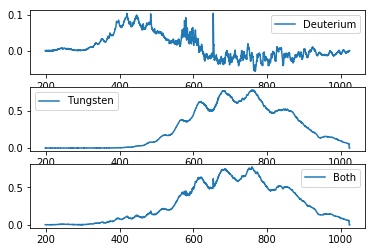

```python
fig=plt.figure()
ax1=fig.add_subplot(311)
ax2=fig.add_subplot(312)
ax3=fig.add_subplot(313)
ax1.plot(xD,yD,label='Deuterium')
ax1.legend()
ax2.plot(xW,yW,label='Tungsten')
ax2.legend()
ax3.plot(xB,yB,label='Both')
ax3.legend()
plt.show()
```

But here we can see that, the space between the plots is not enough, one possible solution for this is changing the size of the figure,

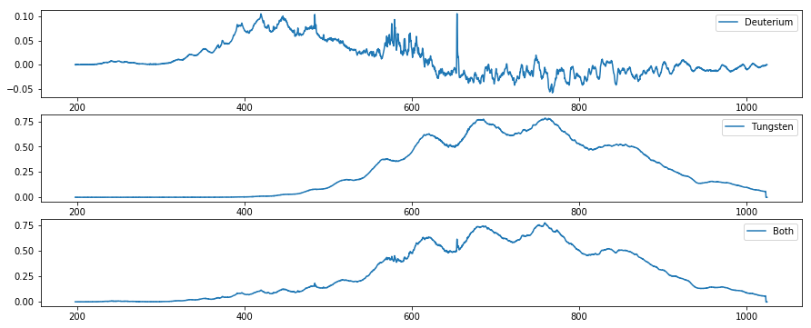

```python
fig=plt.figure(figsize=(15,6))
ax1=fig.add_subplot(311); ax2=fig.add_subplot(312); ax3=fig.add_subplot(313)
ax1.plot(xD,yD,label='Deuterium'); ax1.legend()
ax2.plot(xW,yW,label='Tungsten');ax2.legend()
ax3.plot(xB,yB,label='Both'); ax3.legend()
plt.savefig('plot1.pdf')
plt.show()
```

We can also change the color of the plots, for the default colors,

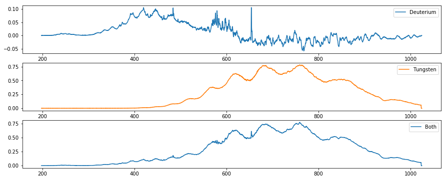

```python
fig=plt.figure(figsize=(15,6))
ax1=fig.add_subplot(311); ax2=fig.add_subplot(312); ax3=fig.add_subplot(313)
ax1.plot(xD,yD,label='Deuterium'); ax1.legend()
ax2.plot(xW,yW,c='C1',label='Tungsten'); ax2.legend()
ax3.plot(xB,yB,label='Both'); ax3.legend()
plt.savefig('plot2.pdf')
plt.show()
```

The numeration starts on $0$

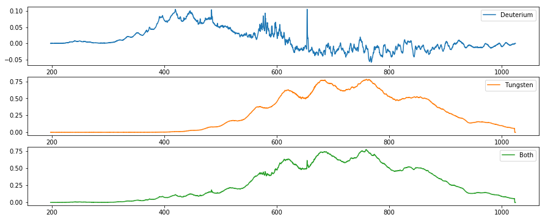

```python
fig=plt.figure(figsize=(15,6))
ax1=fig.add_subplot(311); ax2=fig.add_subplot(312); ax3=fig.add_subplot(313)
ax1.plot(xD,yD,c='C0',label='Deuterium'); ax1.legend()
ax2.plot(xW,yW,c='C1',label='Tungsten'); ax2.legend()
ax3.plot(xB,yB,c='C2',label='Both'); ax3.legend()
plt.savefig('plot3.pdf')
plt.show()
```

A different example, is getting three columns and just one row

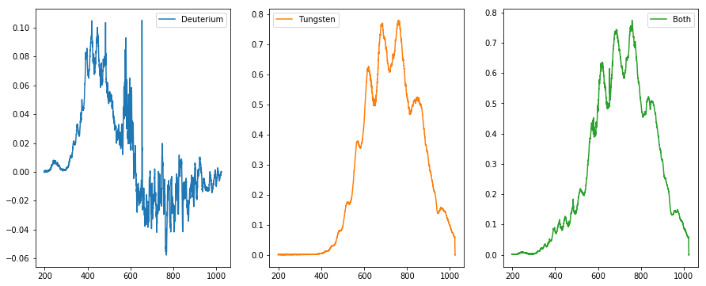

```python
fig=plt.figure(figsize=(15,6))
ax1=fig.add_subplot(131); ax2=fig.add_subplot(132); ax3=fig.add_subplot(133)
ax1.plot(xD,yD,label='Deuterium'); ax1.legend()
ax2.plot(xW,yW,c='C1',label='Tungsten'); ax2.legend()
ax3.plot(xB,yB,c='C2',label='Both'); ax3.legend()
plt.savefig('plot4.pdf')
plt.show()
```

We can arange the plots differently,

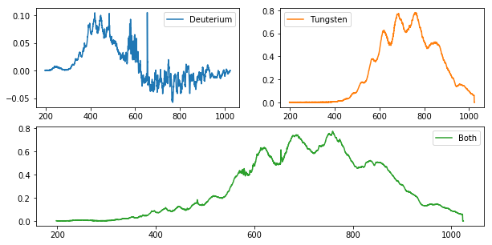

```python
fig=plt.figure(figsize=(10,5))
ax1=fig.add_subplot(221); ax2=fig.add_subplot(222); ax3=fig.add_subplot(212)
ax1.plot(xD,yD,label='Deuterium'); ax1.legend()
ax2.plot(xW,yW,c='C1',label='Tungsten'); ax2.legend()
ax3.plot(xB,yB,c='C2',label='Both'); ax3.legend()
plt.savefig('plot5.pdf')
plt.show()
```

## Lorentz System

Is a system of differential equations which becomes very famous, because it exhibits chaotic behavior with certain combination of paramters,

Named after Edward Lorenz, which during 1963 was developing a simplified mathematical model for atmospheric convection.

$$\frac{dx}{dt}=\sigma(y-x),$$$$\frac{dy}{dt}=x(\rho-z)-y,$$$$\frac{dz}{dt}=xy-\beta z.$$

Where $\sigma$, $\rho$ and $\beta$ are the model parameteres.

The code that solves those equations can be found at the repository on the examples folder [link](https://github.com/jmsevillam/Herramientas-Computacionales-UniAndes/blob/master/examples/Lorentz%20Model/Lorentz.py).

On the following link there is a file with the data, on three columns

| $x$ | $y$ | $z$ |
| --- | --- | --- |

We load just as before,

```python
url='https://raw.githubusercontent.com/jmsevillam/Herramientas-Computacionales-UniAndes/master/examples/Lorentz%20Model/'
data=np.genfromtxt(url+'Lorentz.dat')
```

The data has the exact same structure as before,

```python
print(data)
```

```
[[0.00000000e+00 1.00000000e+00 0.00000000e+00]
 [1.00000000e-01 9.90000000e-01 0.00000000e+00]
 [1.89000000e-01 1.00510000e+00 9.90000000e-04]
 ...
 [5.62775790e+00 6.07865401e+00 2.05607171e+01]
 [5.67284751e+00 6.26769956e+00 2.03545232e+01]
 [5.73233271e+00 6.46855338e+00 2.01672930e+01]]
```

So we must split it into the three columns

```python
x=data[:,0]
y=data[:,1]
z=data[:,2]
```

As we have three coordinates, we can plot the projections,

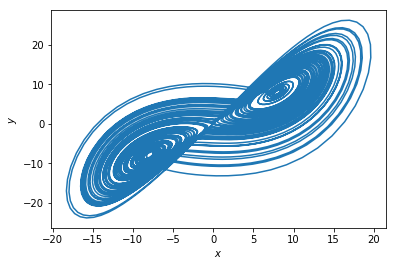

```python
fig=plt.figure()
ax=fig.add_subplot(111)
ax.set_xlabel('$x$')
ax.set_ylabel('$y$')
ax.plot(x,y)
plt.show()
```

On a different axis,

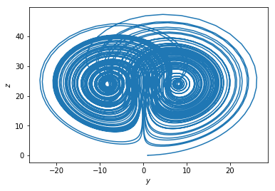

```python
fig=plt.figure()
ax=fig.add_subplot(111)
ax.set_xlabel('$y$')
ax.set_ylabel('$z$')
ax.plot(y,z)
plt.show()
```

And on the last one!

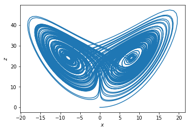

```python
fig=plt.figure()
ax=fig.add_subplot(111)
ax.set_xlabel('$x$')
ax.set_ylabel('$z$')
ax.plot(x,z)
plt.show()
```

If we want to visualize this on the three dimensions, by using another part of `matplotlib`,

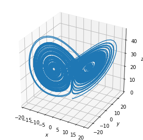

```python
from mpl_toolkits.mplot3d import Axes3D
fig = plt.figure(figsize=(5,5))
ax = fig.add_subplot(111,projection='3d')
ax.set_xlabel('$x$')
ax.set_ylabel('$y$')
ax.set_zlabel('$z$')
ax.plot(x, y, z)
plt.show()
```

The plots do not have to be of the same kind when plotting the axes,

```
[<mpl_toolkits.mplot3d.art3d.Line3D at 0x10edfb4e0>]
```

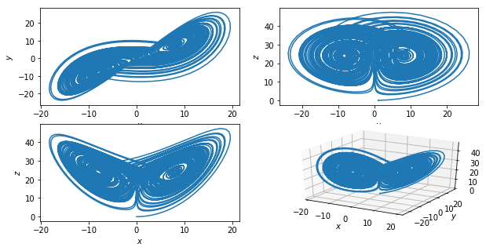

```python
fig = plt.figure(figsize=(10,5))
ax1 = fig.add_subplot(221); ax1.set_xlabel('$x$'); ax1.set_ylabel('$y$')
ax1.plot(x, y)
ax2 = fig.add_subplot(222); ax2.set_xlabel('$y$'); ax2.set_ylabel('$z$')
ax2.plot(y, z)
ax3 = fig.add_subplot(223); ax3.set_xlabel('$x$'); ax3.set_ylabel('$z$')
ax3.plot(x, z)
ax4 = fig.add_subplot(224,projection='3d'); ax4.set_xlabel('$x$'); ax4.set_ylabel('$y$'); ax4.set_zlabel('$z$')
ax4.plot(x, y, z)
```

## Scatter

On `matplotlib`, there are several styles of plotting, a different than `plot`, is the `scater`, which looks like plotting with circles at first sight, but it will allows us to use many options,

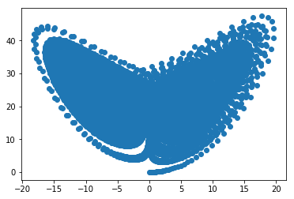

```python
fig=plt.figure()
ax=fig.add_subplot(111)
ax.scatter(x,z)
plt.show()
```

One option is the transparence,

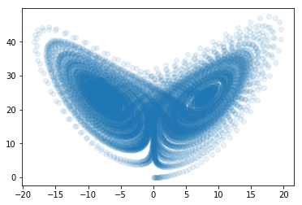

```python
fig=plt.figure()
ax=fig.add_subplot(111)
ax.scatter(x,z,alpha=0.1)
plt.show()
```

another one, is that we can use a pallete with the same or different array,

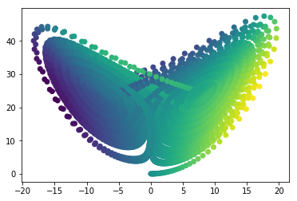

```python
fig=plt.figure()
ax=fig.add_subplot(111)
ax.scatter(x,z,c=y)
plt.show()
```

They can be combinated, and even we can generate a colorbar from there,

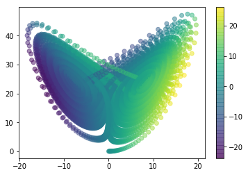

```python
fig=plt.figure()
ax=fig.add_subplot(111)
pl=ax.scatter(x,z,c=y,alpha=0.5)
plt.colorbar(pl)
plt.show()
```

## Surface plots

we are going to explore how to use two methods to plot surfaces, the first one, with the `Axes3d` we have already used, and the other as if we are looking from above and the high is meant to be represented with color, just as a contourplot.

It is necessary that we understand the `numpy.meshgrid` function, to do so, let us create a samall test

```python
x=np.array([1,2])
y=np.array([3,4])
print(np.meshgrid(x,y))
```

```
[array([[1, 2],
       [1, 2]]), array([[3, 3],
       [4, 4]])]
```

It returns two arrays, so we have to separate them as,

```python
X,Y=np.meshgrid(x,y)
print(X)
print(Y)
```

```
[[1 2]
 [1 2]]
[[3 3]
 [4 4]]
```

So, if we think this as the pairs formed from `(X[i,j],Y[i,j])`, they are all the possible combinations of the values of `x` and `y`.

For the surface plotting, first, we define a function we want to plot. (This example is thought to be on polar coordinates).

```python
def f(r):
    return np.exp(-r/5)*np.cos(3*r)
```

We have to define the points where we are going to generate the plot.

```python
x=np.linspace(-5,5,1000)
y=np.linspace(-5,5,1000)
```

Create a grid, and from there, we create another grid with the radious information (Polar coordinates),

```python
X,Y=np.meshgrid(x,y)
R=np.sqrt(X**2+Y**2)
```

We use the function we want to test,

```python
Z=f(R)
```

Finally we can plot these matrices with the `plot_surface` method,

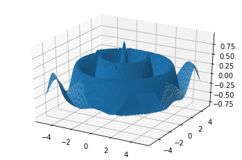

```python
fig = plt.figure()
ax = fig.add_subplot(111,projection='3d')
surf = ax.plot_surface(X, Y, Z)
plt.show()
```

The other way, only needs one parameter, and uses `range`s for the coordinates

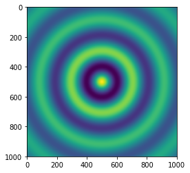

```python
fig = plt.figure()
ax = fig.add_subplot(111)
ax.imshow(Z)
plt.show()
```